# Tennis davis Cup

Martí Casals & Jordi Cortes

2023-12-11

## Introduction

### Data

The clean database is in the file:

- *../Data/data_2023-03-30.Rdata*.

### Additional debugging

- **Walk overs** (n = 24) are removed.
- The average age variable of the players is constructed
- Fixed some factors

First registers of data.

```
##   tourney_id                tourney_name        group Ronda round surface
## 1  2000-D078 Davis Cup G1 QF: JPN vs KOR No Mundial 1    QF    QF  Carpet
## 2  2000-D078 Davis Cup G1 QF: JPN vs KOR No Mundial 1    QF    QF  Carpet
## 3  2000-D078 Davis Cup G1 QF: JPN vs KOR No Mundial 1    QF    QF  Carpet
##   tourney_level match_num winner_id      winner_name winner_hand winner_ht
## 1     Davis Cup         1    102703   Hyung Taik Lee           R       180
## 2     Davis Cup         2    102300 Gouichi Motomura           R       173
## 3     Davis Cup         3    102703   Hyung Taik Lee           R       180
##   winner_ioc winner_age winner_rank winner_rank_points loser_id
## 1        KOR      24.09          19                 17   102982
## 2        JPN      26.11          15                 25   102263
## 3        KOR      24.09          19                 17   102300
##         loser_name loser_hand loser_ht loser_ioc loser_age loser_rank
## 1      Yaoki Ishii          R      170       JPN     22.77         21
## 2     Yong Il Yoon          R      175       KOR     26.37         36
## 3 Gouichi Motomura          R      173       JPN     26.11         15
##   loser_rank_points                score best_of round.1 minutes W1 W2 W3 W4 W5
## 1                15 4-6 4-6 6-2 6-1 10-8   5sets      RR      NA  4  4  6  6 10
## 2                76  6-3 4-6 6-4 2-6 6-3   5sets      RR      NA  6  4  6  2  6
## 3                25          7-5 6-4 7-5   5sets      RR      NA  7  6  7 NA NA
##   L1 L2 L3 L4 L5 Retirement  tourney_start_date year    match_id
## 1  6  6  2  1  8         No 2000-02-04 00:00:00 2000 2000-D078:1
## 2  3  6  4  6  3         No 2000-02-04 00:00:00 2000 2000-D078:2
## 3  5  4  5 NA NA         No 2000-02-04 00:00:00 2000 2000-D078:3
##   Retirement_factor Source_factor_retirement Location.Home_Away Reason
## 1
## 2
## 3
##   Body.Region sum_score sum_age sum_height sum_rank dif_age dif_height dif_rank
## 1                    53   46.86        350       40    1.32         10        2
## 2                    46   52.48        348       51    0.26          2       21
## 3                    34   50.20        353       34    2.02          7        4
##   mean_age mean_age_cat Retirement_num round_cat mean_age_ind year_cat
## 1    23.43           23              0     Final          <27    <2010
## 2    26.24           26              0     Final          <27    <2010
## 3    25.10           25              0     Final          <27    <2010
##   year_center    WO
## 1          -9 FALSE
## 2          -9 FALSE
## 3          -9 FALSE
```

# Descriptive analysis

## Covariates

### Data Frame Summary

#### dades

**Dimensions:** 6036 x 7  
**Duplicates:** 0

| No | Variable | Stats / Values | Freqs (% of Valid) | Graph | Valid | Missing |
| --- | --- | --- | --- | --- | --- | --- |
| 1 | surface [factor] | 1. Clay 2. Carpet 3. Grass 4. Hard | 2267 (37.6%) 608 (10.1%) 174 ( 2.9%) 2987 (49.5%) |  | 6036 (100.0%) | 0 (0.0%) |
| 2 | best_of [factor] | 1. 3sets 2. 5sets | 1933 (32.0%) 4103 (68.0%) |  | 6036 (100.0%) | 0 (0.0%) |
| 3 | group [factor] | 1. No Mundial 1 2. Mundial 1 | 4263 (70.6%) 1773 (29.4%) |  | 6036 (100.0%) | 0 (0.0%) |
| 4 | year [integer] | Mean (sd) : 2008.9 (5.5) min < med < max: 2000 < 2009 < 2019 IQR (CV) : 10 (0) | 20 distinct values |  | 6036 (100.0%) | 0 (0.0%) |
| 5 | sum_age [numeric] | Mean (sd) : 49.4 (6.1) min < med < max: 33.4 < 49.3 < 72.1 IQR (CV) : 8.4 (0.1) | 2427 distinct values |  | 6036 (100.0%) | 0 (0.0%) |
| 6 | dif_age [numeric] | Mean (sd) : 4.3 (3.3) min < med < max: 0 < 3.6 < 25.6 IQR (CV) : 4.5 (0.8) | 1519 distinct values |  | 6036 (100.0%) | 0 (0.0%) |
| 7 | match_num [factor] | 1. 1 2. 2 3. 3 4. 4 | 1570 (26.0%) 1570 (26.0%) 1531 (25.4%) 1365 (22.6%) |  | 6036 (100.0%) | 0 (0.0%) |

## Retirements

The proportion of withdrawals in our sample is 0.032. That is, 3.2%.

| Retirements | Number |
| --- | --- |
| No | 5845 |
| Yes | 191 |

Retirements by group:

```
##               Retirement
## group            No  Yes
##   No Mundial 1 4120  143
##   Mundial 1    1725   48
```

## Bivariate descriptive analysis

```
##
##  --- Descriptives of each row-variable by groups of 'Retirement' ---
##
## -------------------
## row-variable: surface
##
##       Carpet Clay Grass Hard Carpet%  Clay%    Grass%   Hard%    p.overall
## [ALL] 608    2267 174   2987 10.0729  37.55799 2.882704 49.48641
## No    598    2200 168   2879 98.35526 97.04455 96.55172 96.38433 0.073961
## Yes   10     67   6     108  1.644737 2.955448 3.448276 3.615668
##
##        OR       OR.lower OR.upper
## Carpet 1
## Clay   1.796299 0.960936 3.751828
## Grass  2.155094 0.709823 5.975612
## Hard   2.210599 1.207897 4.552318
##
## -------------------
## row-variable: best_of
##
##       3sets 5sets 3sets%   5sets%   p.overall
## [ALL] 1933  4103  32.02452 67.97548
## No    1907  3938  98.65494 95.97855 0
## Yes   26    165   1.345059 4.021448
##
##       OR       OR.lower OR.upper
## 3sets 1
## 5sets 3.056611 2.051048 4.747324
##
## -------------------
## row-variable: group
##
##       No Mundial 1 Mundial 1 No Mundial 1% Mundial 1% p.overall
## [ALL] 4263         1773      70.62624      29.37376
## No    4120         1725      96.64555      97.29272   0.219617
## Yes   143          48        3.354445      2.707276
##
##              OR       OR.lower OR.upper
## No Mundial 1 1
## Mundial 1    0.803517 0.570989 1.111332
```

[output cut: 33 more lines]

```
## Yes   191  20.63874 11.30116 19.02576 22.25173
##
##      OR       OR.lower OR.upper
## [1,] 0.882298 0.864287 0.900685
##
## -------------------
## row-variable: mean_age
##
##       N    mean     sd       lower    upper    p.overall
## [ALL] 6036 24.70169 3.047436 24.6248  24.77859
## No    5845 24.71085 3.036441 24.63299 24.78871 0.241785
## Yes   191  24.42137 3.363297 23.94133 24.9014
##
##      OR       OR.lower OR.upper
## [1,] 0.969033 0.923863 1.01641
```

```
##
## --------Summary descriptives table by 'Retirement'---------
##
## _________________________________________
##                       No          Yes
##                     N=5845       N=191
## ¯¯¯¯¯¯¯¯¯¯¯¯¯¯¯¯¯¯¯¯¯¯¯¯¯¯¯¯¯¯¯¯¯¯¯¯¯¯¯¯¯
## surface:
##     Carpet       598 (98.4%)  10 (1.64%)
##     Clay         2200 (97.0%) 67 (2.96%)
##     Grass        168 (96.6%)   6 (3.45%)
##     Hard         2879 (96.4%) 108 (3.62%)
## best_of:
##     3sets        1907 (98.7%) 26 (1.35%)
##     5sets        3938 (96.0%) 165 (4.02%)
## group:
##     No Mundial 1 4120 (96.6%) 143 (3.35%)
##     Mundial 1    1725 (97.3%) 48 (2.71%)
## round_cat:
##     Preliminar   4877 (96.8%) 160 (3.18%)
##     Final        968 (96.9%)  31 (3.10%)
## match_num:
##     1            1532 (97.6%) 38 (2.42%)
##     2            1525 (97.1%) 45 (2.87%)
##     3            1474 (96.3%) 57 (3.72%)
##     4            1314 (96.3%) 51 (3.74%)
## sum_score        30.4 (10.7)  20.6 (11.3)
## mean_age         24.7 (3.04)  24.4 (3.36)
## ¯¯¯¯¯¯¯¯¯¯¯¯¯¯¯¯¯¯¯¯¯¯¯¯¯¯¯¯¯¯¯¯¯¯¯¯¯¯¯¯¯
```

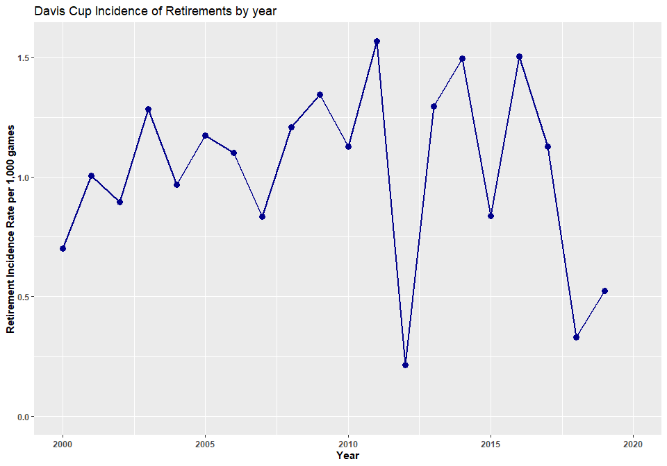

```
##     x     pt    rate     lower    upper conf.level
## 1 191 181414 1.05284 0.9088162 1.213206       0.95
```

```
##              Outcome +    Time at risk                 Inc rate *
## Exposed +           67           67669        0.10 (0.08 to 0.13)
## Exposed -           10           19685        0.05 (0.02 to 0.09)
## Total               77           87354        0.09 (0.07 to 0.11)
##
## Point estimates and 95% CIs:
## -------------------------------------------------------------------
## Inc rate ratio                                 1.95 (1.00, 4.25)
## Attrib rate in the exposed *                   0.05 (0.01, 0.09)
## Attrib fraction in the exposed (%)            48.69 (-0.31, 76.47)
## Attrib rate in the population *                0.04 (0.00, 0.07)
## Attrib fraction in the population (%)         42.37 (15.20, 64.98)
## -------------------------------------------------------------------
##  Wald confidence limits
##  CI: confidence interval
##  * Outcomes per 100 units of population time at risk
```

```
##              Outcome +    Time at risk                 Inc rate *
## Exposed +           67           67669        0.10 (0.08 to 0.13)
## Exposed -           10           19685        0.05 (0.02 to 0.09)
## Total               77           87354        0.09 (0.07 to 0.11)
##
## Point estimates and 95% CIs:
## -------------------------------------------------------------------
## Inc rate ratio                                 1.95 (1.00, 4.25)
## Attrib rate in the exposed *                   0.05 (0.01, 0.09)
## Attrib fraction in the exposed (%)            48.69 (-0.31, 76.47)
## Attrib rate in the population *                0.04 (0.00, 0.07)
## Attrib fraction in the population (%)         42.37 (15.20, 64.98)
## -------------------------------------------------------------------
##  Wald confidence limits
##  CI: confidence interval
##  * Outcomes per 100 units of population time at risk
```

```
##    surface Retirement Count  Prop
## 1:  Carpet         No   598  9.91
## 2:  Carpet        Yes    10  0.17
## 3:    Clay         No  2200 36.45
## 4:    Clay        Yes    67  1.11
## 5:   Grass         No   168  2.78
## 6:   Grass        Yes     6  0.10
## 7:    Hard         No  2879 47.70
## 8:    Hard        Yes   108  1.79
```

```
##
##       Carpet Clay Grass Hard
##   No     598 2200   168 2879
##   Yes     10   67     6  108
```

```
##   surface sum_score
## 1  Carpet     19685
## 2    Clay     67669
## 3   Grass      5494
## 4    Hard     88566
```

```
##              Outcome +    Time at risk                 Inc rate *
## Exposed +           67           67669        0.99 (0.77 to 1.26)
## Exposed -           10           19685        0.51 (0.24 to 0.93)
## Total               77           87354        0.88 (0.70 to 1.10)
##
## Point estimates and 95% CIs:
## -------------------------------------------------------------------
## Inc rate ratio                                 1.95 (1.00, 4.25)
## Attrib rate in the exposed *                   0.48 (0.09, 0.88)
## Attrib fraction in the exposed (%)            48.69 (-0.31, 76.47)
## Attrib rate in the population *                0.37 (0.00, 0.74)
## Attrib fraction in the population (%)         42.37 (15.20, 64.98)
## -------------------------------------------------------------------
##  Wald confidence limits
##  CI: confidence interval
##  * Outcomes per 1000 units of population time at risk
```

```
##              Outcome +    Time at risk                 Inc rate *
## Exposed +            6            5494        1.09 (0.40 to 2.38)
## Exposed -           10           19685        0.51 (0.24 to 0.93)
## Total               16           25179        0.64 (0.36 to 1.03)
##
## Point estimates and 95% CIs:
## -------------------------------------------------------------------
## Inc rate ratio                                 2.15 (0.64, 6.53)
## Attrib rate in the exposed *                   0.58 (-0.34, 1.51)
## Attrib fraction in the exposed (%)            53.48 (-55.73, 84.68)
## Attrib rate in the population *                0.13 (-0.32, 0.57)
## Attrib fraction in the population (%)         20.06 (9.47, 32.93)
## -------------------------------------------------------------------
##  Wald confidence limits
##  CI: confidence interval
##  * Outcomes per 1000 units of population time at risk
```

```
##              Outcome +    Time at risk                 Inc rate *
## Exposed +          108           88566        1.22 (1.00 to 1.47)
## Exposed -           10           19685        0.51 (0.24 to 0.93)
## Total              118          108251        1.09 (0.90 to 1.31)
##
## Point estimates and 95% CIs:
## -------------------------------------------------------------------
## Inc rate ratio                                 2.40 (1.26, 5.15)
## Attrib rate in the exposed *                   0.71 (0.32, 1.10)
## Attrib fraction in the exposed (%)            58.34 (20.40, 80.57)
## Attrib rate in the population *                0.58 (0.21, 0.95)
## Attrib fraction in the population (%)         53.40 (28.43, 73.00)
## -------------------------------------------------------------------
##  Wald confidence limits
##  CI: confidence interval
##  * Outcomes per 1000 units of population time at risk
```

```
##    best_of Retirement Count  Prop
## 1:   5sets         No  3938 65.24
## 2:   3sets         No  1907 31.59
## 3:   5sets        Yes   165  2.73
## 4:   3sets        Yes    26  0.43
```

```
##
##       3sets 5sets
##   No   1907  3938
##   Yes    26   165
```

```
##   best_of sum_score
## 1   3sets     41386
## 2   5sets    140028
```

```
##              Outcome +    Time at risk                 Inc rate *
## Exposed +          165          140028        1.18 (1.01 to 1.37)
## Exposed -           26           41386        0.63 (0.41 to 0.92)
## Total              191          181414        1.05 (0.91 to 1.21)
##
## Point estimates and 95% CIs:
## -------------------------------------------------------------------
## Inc rate ratio                                 1.88 (1.24, 2.96)
## Attrib rate in the exposed *                   0.55 (0.25, 0.85)
## Attrib fraction in the exposed (%)            46.68 (19.05, 66.17)
## Attrib rate in the population *                0.42 (0.14, 0.71)
## Attrib fraction in the population (%)         40.33 (24.13, 54.84)
## -------------------------------------------------------------------
##  Wald confidence limits
##  CI: confidence interval
##  * Outcomes per 1000 units of population time at risk
```

```
##           group Retirement Count  Prop
## 1: No Mundial 1         No  4120 68.26
## 2:    Mundial 1         No  1725 28.58
## 3: No Mundial 1        Yes   143  2.37
## 4:    Mundial 1        Yes    48  0.80
```

```
##
##       No Mundial 1 Mundial 1
##   No          4120      1725
##   Yes          143        48
```

```
##          group sum_score
## 1 No Mundial 1    124970
## 2    Mundial 1     56444
```

```
##              Outcome +    Time at risk                 Inc rate *
## Exposed +          143          124970        1.14 (0.96 to 1.35)
## Exposed -           48           56444        0.85 (0.63 to 1.13)
## Total              191          181414        1.05 (0.91 to 1.21)
##
## Point estimates and 95% CIs:
## -------------------------------------------------------------------
## Inc rate ratio                                 1.35 (0.96, 1.91)
## Attrib rate in the exposed *                   0.29 (-0.01, 0.60)
## Attrib fraction in the exposed (%)            25.68 (-3.73, 47.56)
## Attrib rate in the population *                0.20 (-0.08, 0.49)
## Attrib fraction in the population (%)         19.23 (7.06, 31.01)
## -------------------------------------------------------------------
##  Wald confidence limits
##  CI: confidence interval
##  * Outcomes per 1000 units of population time at risk
```

```
##     round_cat Retirement Count  Prop
## 1:      Final         No   968 16.04
## 2: Preliminar         No  4877 80.80
## 3: Preliminar        Yes   160  2.65
## 4:      Final        Yes    31  0.51
```

```
##
##       Preliminar Final
##   No        4877   968
##   Yes        160    31
```

```
##    round_cat sum_score
## 1 Preliminar    149780
## 2      Final     31634
```

```
##              Outcome +    Time at risk                 Inc rate *
## Exposed +          160          149780        1.07 (0.91 to 1.25)
## Exposed -           31           31634        0.98 (0.67 to 1.39)
## Total              191          181414        1.05 (0.91 to 1.21)
##
## Point estimates and 95% CIs:
## -------------------------------------------------------------------
## Inc rate ratio                                 1.09 (0.74, 1.66)
## Attrib rate in the exposed *                   0.09 (-0.29, 0.47)
## Attrib fraction in the exposed (%)            8.26 (-35.42, 39.67)
## Attrib rate in the population *                0.07 (-0.30, 0.45)
## Attrib fraction in the population (%)         6.92 (-14.65, 26.74)
## -------------------------------------------------------------------
##  Wald confidence limits
##  CI: confidence interval
##  * Outcomes per 1000 units of population time at risk
```

```
##    match_num Retirement Count  Prop
## 1:         1         No  1532 25.38
## 2:         2         No  1525 25.27
## 3:         3         No  1474 24.42
## 4:         4         No  1314 21.77
## 5:         3        Yes    57  0.94
## 6:         1        Yes    38  0.63
## 7:         4        Yes    51  0.84
## 8:         2        Yes    45  0.75
```

```
##
##          1    2    3    4
##   No  1532 1525 1474 1314
##   Yes   38   45   57   51
```

```
##   match_num sum_score
## 1         1     51755
## 2         2     52472
## 3         3     44041
## 4         4     33146
```

```
##              Outcome +    Time at risk                 Inc rate *
## Exposed +           45           52472        0.86 (0.63 to 1.15)
## Exposed -           38           51755        0.73 (0.52 to 1.01)
## Total               83          104227        0.80 (0.63 to 0.99)
##
## Point estimates and 95% CIs:
## -------------------------------------------------------------------
## Inc rate ratio                                 1.17 (0.74, 1.85)
## Attrib rate in the exposed *                   0.12 (-0.22, 0.47)
## Attrib fraction in the exposed (%)            14.39 (-34.86, 45.91)
## Attrib rate in the population *                0.06 (-0.23, 0.35)
## Attrib fraction in the population (%)         7.80 (-2.09, 18.08)
## -------------------------------------------------------------------
##  Wald confidence limits
##  CI: confidence interval
##  * Outcomes per 1000 units of population time at risk
```

```
##              Outcome +    Time at risk                 Inc rate *
## Exposed +           57           44041        1.29 (0.98 to 1.68)
## Exposed -           38           51755        0.73 (0.52 to 1.01)
## Total               95           95796        0.99 (0.80 to 1.21)
##
## Point estimates and 95% CIs:
## -------------------------------------------------------------------
## Inc rate ratio                                 1.76 (1.15, 2.73)
## Attrib rate in the exposed *                   0.56 (0.15, 0.97)
## Attrib fraction in the exposed (%)            43.27 (12.97, 63.39)
## Attrib rate in the population *                0.26 (-0.05, 0.56)
## Attrib fraction in the population (%)         25.96 (16.87, 35.24)
## -------------------------------------------------------------------
##  Wald confidence limits
##  CI: confidence interval
##  * Outcomes per 1000 units of population time at risk
```

```
##              Outcome +    Time at risk                 Inc rate *
## Exposed +           51           33146        1.54 (1.15 to 2.02)
## Exposed -           38           51755        0.73 (0.52 to 1.01)
## Total               89           84901        1.05 (0.84 to 1.29)
##
## Point estimates and 95% CIs:
## -------------------------------------------------------------------
## Inc rate ratio                                 2.10 (1.35, 3.28)
## Attrib rate in the exposed *                   0.80 (0.32, 1.29)
## Attrib fraction in the exposed (%)            52.28 (25.93, 69.50)
## Attrib rate in the population *                0.31 (-0.01, 0.63)
## Attrib fraction in the population (%)         29.96 (21.88, 38.28)
## -------------------------------------------------------------------
##  Wald confidence limits
##  CI: confidence interval
##  * Outcomes per 1000 units of population time at risk
```

## Interactions

We study interactions by a decision tree.

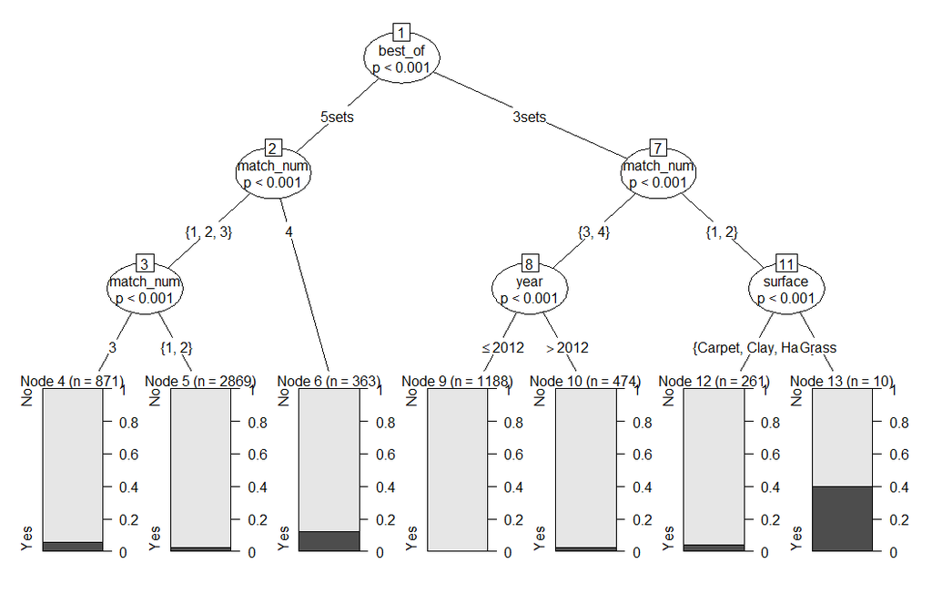

## Lineality

### Age

Age is not linear as can be seen in the following figures.

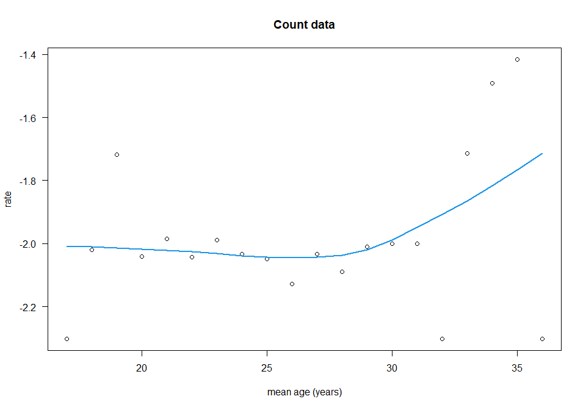

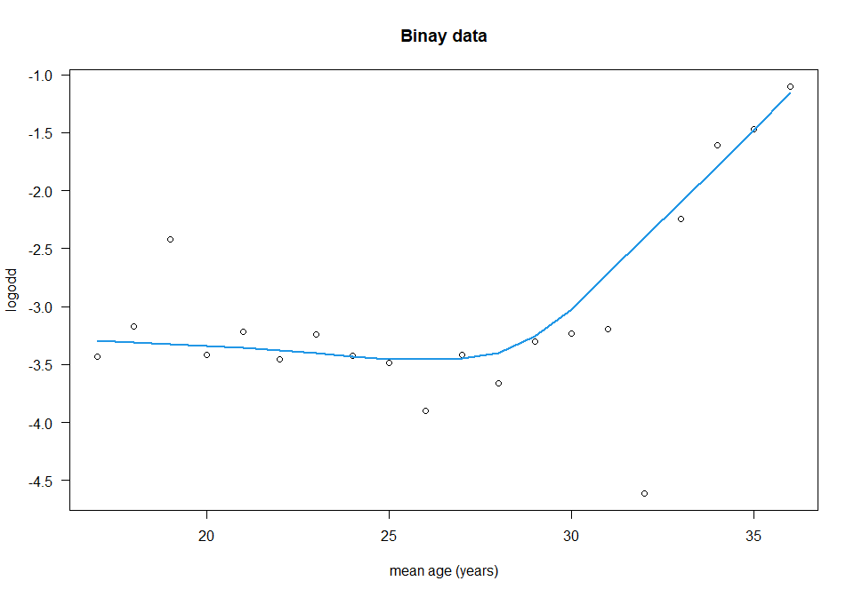

### Year

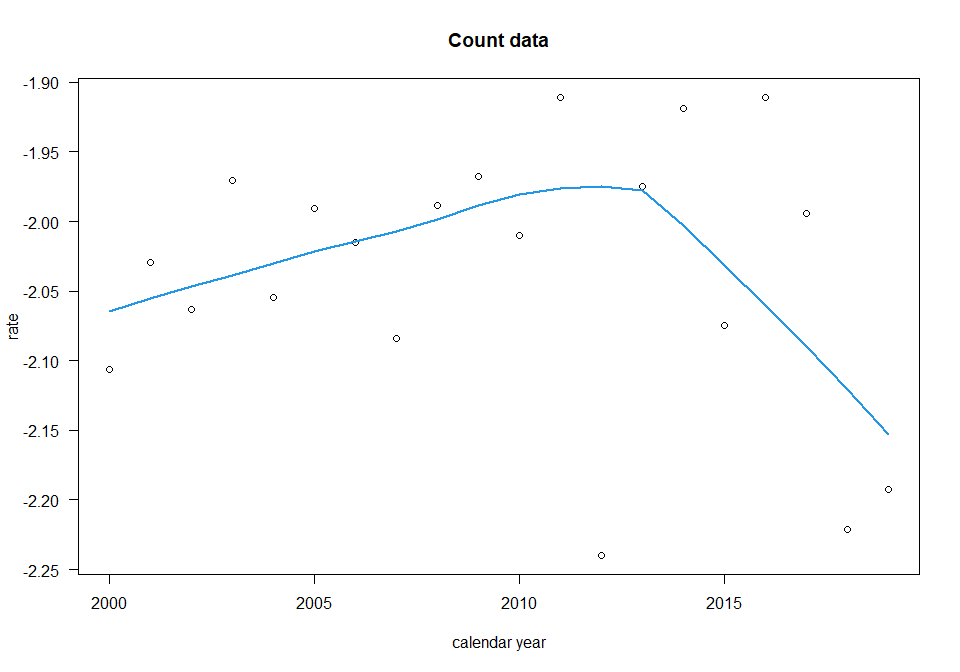

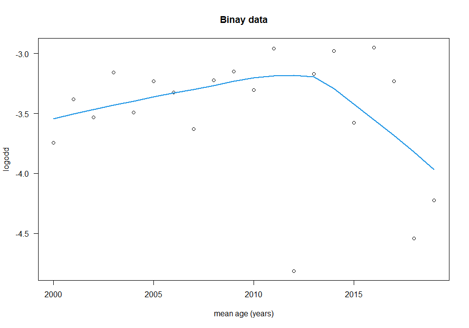

# Models

## Count data model

- The logarithm of the number of games is included as offset
- The year is included centered and as a quadratic polynomial
- Two slopes are included for middle age (before and after 27 years)

ANOVA (Type II) of the first additive model:

```
## Analysis of Deviance Table (Type II tests)
##
## Response: Retirement_num
##                       LR Chisq Df Pr(>Chisq)
## surface                  9.663  3   0.021655 *
## best_of                 39.260  1  3.709e-10 ***
## year_center              0.107  1   0.743468
## I(year_center^2)         0.440  1   0.507080
## mean_age                 4.833  1   0.027915 *
## mean_age_ind             0.745  1   0.388153
## match_num               38.729  3  1.981e-08 ***
## round_cat                0.000  1   0.987852
## group                    0.754  1   0.385251
## mean_age:mean_age_ind    7.637  1   0.005717 **
## ---
## Signif. codes:  0 '***' 0.001 '**' 0.01 '*' 0.05 '.' 0.1 ' ' 1
```

Overdispersion? No

```
##
##  Overdispersion test
##
## data:  model0
## z = -6.9968, p-value = 1
## alternative hypothesis: true alpha is greater than 0
## sample estimates:
##       alpha
## -0.03164347
```

```
##
##  Overdispersion test
##
## data:  model0
## z = -0.9024, p-value = 0.8166
## alternative hypothesis: true alpha is greater than 0
## sample estimates:
##       alpha
## -0.09688721
```

Interactions are proposed and a stepwise is made to find a better model according to the BIC criterion and then surface and the interaction with age are added.

```
##
## Call:
## glm(formula = Retirement_num ~ surface + mean_age * mean_age_ind +
##     best_of * match_num, family = "poisson", data = dd, offset = log(sum_score))
##
## Deviance Residuals:
##     Min       1Q   Median       3Q      Max
## -0.9212  -0.2722  -0.2008  -0.1333   3.4080
##
## Coefficients:
##                          Estimate Std. Error z value Pr(>|z|)
## (Intercept)              -3.74440    1.02270  -3.661 0.000251 ***
## surfaceClay               0.71274    0.33941   2.100 0.035735 *
## surfaceGrass              0.75194    0.51790   1.452 0.146532
## surfaceHard               0.92478    0.33176   2.788 0.005311 **
## mean_age                 -0.14036    0.03765  -3.728 0.000193 ***
## mean_age_ind>27          -7.70741    2.80479  -2.748 0.005997 **
## best_of5sets             -0.96115    0.44676  -2.151 0.031447 *
## match_num2                0.27044    0.54009   0.501 0.616554
## match_num3               -1.53494    0.58022  -2.645 0.008159 **
## match_num4               -2.01889    0.58166  -3.471 0.000519 ***
## mean_age:mean_age_ind>27  0.28121    0.09823   2.863 0.004199 **
## best_of5sets:match_num2  -0.16132    0.59162  -0.273 0.785105
## best_of5sets:match_num3   2.50243    0.62294   4.017 5.89e-05 ***
## best_of5sets:match_num4   3.72640    0.62510   5.961 2.50e-09 ***
## ---
## Signif. codes:  0 '***' 0.001 '**' 0.01 '*' 0.05 '.' 0.1 ' ' 1
##
## (Dispersion parameter for poisson family taken to be 1)
##
##     Null deviance: 1531.3  on 6035  degrees of freedom
## Residual deviance: 1400.5  on 6022  degrees of freedom
## AIC: 1810.5
##
## Number of Fisher Scoring iterations: 7
```

### Best model according BIC adding surface and interaction with age

Final model:

```
##
## Call:
## glm(formula = Retirement_num ~ surface + mean_age * mean_age_ind +
##     best_of * match_num, family = "poisson", data = dd, offset = log(sum_score))
##
## Deviance Residuals:
##     Min       1Q   Median       3Q      Max
## -0.9212  -0.2722  -0.2008  -0.1333   3.4080
##
## Coefficients:
##                          Estimate Std. Error z value Pr(>|z|)
## (Intercept)              -3.74440    1.02270  -3.661 0.000251 ***
## surfaceClay               0.71274    0.33941   2.100 0.035735 *
## surfaceGrass              0.75194    0.51790   1.452 0.146532
## surfaceHard               0.92478    0.33176   2.788 0.005311 **
## mean_age                 -0.14036    0.03765  -3.728 0.000193 ***
## mean_age_ind>27          -7.70741    2.80479  -2.748 0.005997 **
## best_of5sets             -0.96115    0.44676  -2.151 0.031447 *
## match_num2                0.27044    0.54009   0.501 0.616554
## match_num3               -1.53494    0.58022  -2.645 0.008159 **
## match_num4               -2.01889    0.58166  -3.471 0.000519 ***
## mean_age:mean_age_ind>27  0.28121    0.09823   2.863 0.004199 **
## best_of5sets:match_num2  -0.16132    0.59162  -0.273 0.785105
## best_of5sets:match_num3   2.50243    0.62294   4.017 5.89e-05 ***
## best_of5sets:match_num4   3.72640    0.62510   5.961 2.50e-09 ***
## ---
## Signif. codes:  0 '***' 0.001 '**' 0.01 '*' 0.05 '.' 0.1 ' ' 1
##
## (Dispersion parameter for poisson family taken to be 1)
##
##     Null deviance: 1531.3  on 6035  degrees of freedom
## Residual deviance: 1400.5  on 6022  degrees of freedom
## AIC: 1810.5
##
## Number of Fisher Scoring iterations: 7
```

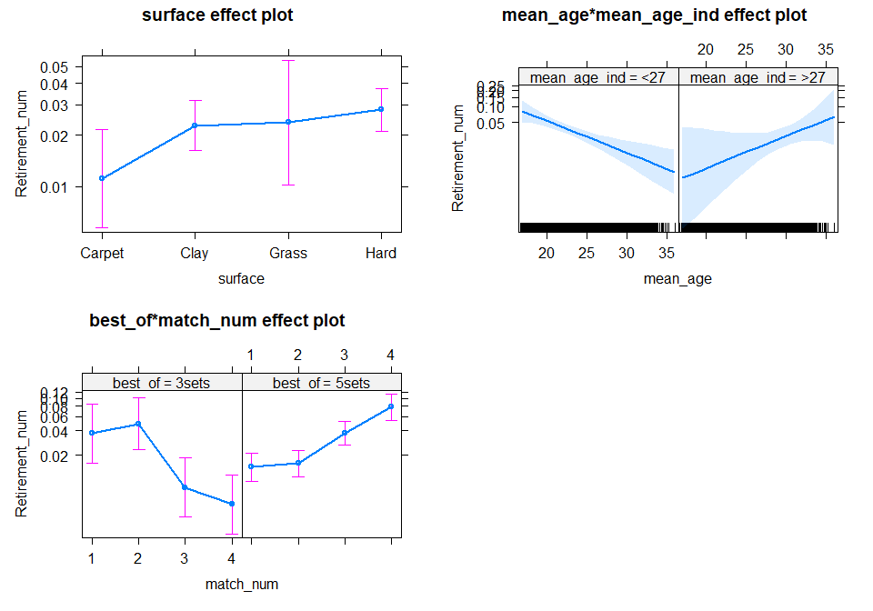

### Forest plot

Next figure shows the incidence Rate Ratio for the different factors in study.

Regarding the **surfaces**, the rate of retirements in Clay, Hard or Grass is more than double than in the carpet surface, being the two formers statistically significant.

The behavior of retirements is different depending on the **age** of participants. If they are younger (mean age below 27), then the incidence rate (IR) of retirements is the half for a 5 years increase. Meanwhile, if the mean age of the players is at least 27 years, then the IR doubles for 5 years increase, but not statistical significantly.

Finally, the **number of individual match** also plays a role in the retirements but it depends on the number of sets for the eliminatory: - If the matches are at best of 3 sets, retirements are less usual in 3rd and 4th matches. - Oppositely, if the matches are at best of 5 sets, retirements are more prone to be produced in 3rd and 4th matches.

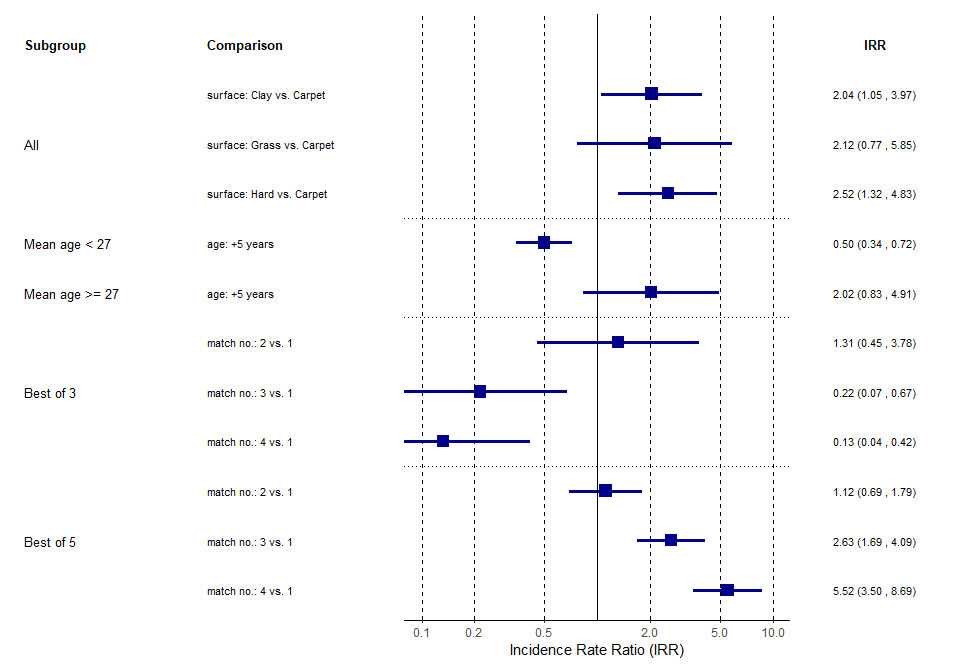

## Logistic Models

### Fitting

The same variables are put in as in counts and the following model is obtained that will be used to calculate the probabilities of withdrawals.

```
##
## Call:
## glm(formula = form, family = "binomial", data = dd)
##
## Deviance Residuals:
##     Min       1Q   Median       3Q      Max
## -0.7650  -0.2763  -0.2053  -0.1341   3.3366
##
## Coefficients:
##                          Estimate Std. Error z value Pr(>|z|)
## (Intercept)              -0.55926    1.05933  -0.528 0.597545
## surfaceClay               0.66958    0.34608   1.935 0.053020 .
## surfaceGrass              0.77090    0.53312   1.446 0.148170
## surfaceHard               0.86953    0.33829   2.570 0.010160 *
## mean_age                 -0.13777    0.03914  -3.520 0.000431 ***
## mean_age_ind>27          -8.09598    2.95666  -2.738 0.006177 **
## best_of5sets             -0.62646    0.45770  -1.369 0.171087
## match_num2                0.31171    0.55575   0.561 0.574870
## match_num3               -1.68924    0.58990  -2.864 0.004189 **
## match_num4               -2.17447    0.59102  -3.679 0.000234 ***
## mean_age:mean_age_ind>27  0.29447    0.10355   2.844 0.004457 **
## best_of5sets:match_num2  -0.18515    0.60733  -0.305 0.760472
## best_of5sets:match_num3   2.72024    0.63397   4.291 1.78e-05 ***
## best_of5sets:match_num4   3.97620    0.63777   6.235 4.53e-10 ***
## ---
## Signif. codes:  0 '***' 0.001 '**' 0.01 '*' 0.05 '.' 0.1 ' ' 1
##
## (Dispersion parameter for binomial family taken to be 1)
##
##     Null deviance: 1695.0  on 6035  degrees of freedom
## Residual deviance: 1536.7  on 6022  degrees of freedom
## AIC: 1564.7
##
## Number of Fisher Scoring iterations: 7
```

### Validation

Residuals validate the model.

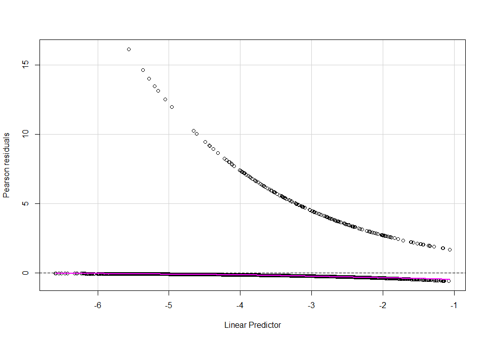

### Interpretation

The following plot shows all the effects:

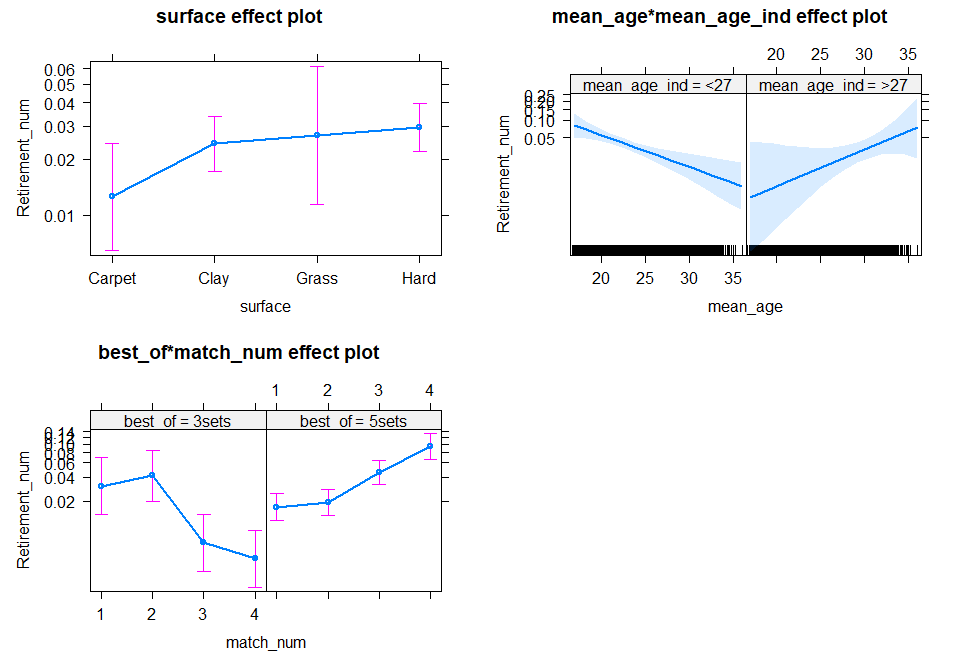

### Probabilities

We use the emmeans package to understand the effects.

| Variable | Subgroup | Category | prob | lower | upper |
| --- | --- | --- | --- | --- | --- |
| Surface | All | Carpet | 0.008 | 0.004 | 0.019 |
| Surface | All | Clay | 0.016 | 0.010 | 0.028 |
| Surface | All | Grass | 0.018 | 0.007 | 0.047 |
| Surface | All | Hard | 0.020 | 0.012 | 0.033 |
| Age | Age < 27 | 18 | 0.055 | 0.034 | 0.088 |
| Age | Age < 27 | 20 | 0.042 | 0.029 | 0.062 |
| Age | Age < 27 | 22 | 0.032 | 0.023 | 0.045 |
| Age | Age < 27 | 24 | 0.025 | 0.018 | 0.034 |
| Age | Age < 27 | 26 | 0.019 | 0.013 | 0.028 |
| Age | Age >= 27 | 28 | 0.017 | 0.010 | 0.027 |
| Age | Age >= 27 | 30 | 0.023 | 0.015 | 0.035 |
| Age | Age >= 27 | 32 | 0.031 | 0.016 | 0.057 |
| Age | Age >= 27 | 34 | 0.042 | 0.016 | 0.102 |
| Age | Age >= 27 | 36 | 0.056 | 0.016 | 0.181 |
| Match no. | Best of 3 sets | 1 | 0.022 | 0.008 | 0.057 |
| Match no. | Best of 3 sets | 2 | 0.030 | 0.012 | 0.070 |
| Match no. | Best of 3 sets | 3 | 0.004 | 0.002 | 0.011 |
| Match no. | Best of 3 sets | 4 | 0.003 | 0.001 | 0.007 |
| Match no. | Best of 5 sets | 1 | 0.012 | 0.006 | 0.022 |
| Match no. | Best of 5 sets | 2 | 0.013 | 0.007 | 0.024 |
| Match no. | Best of 5 sets | 3 | 0.033 | 0.019 | 0.056 |
| Match no. | Best of 5 sets | 4 | 0.068 | 0.038 | 0.117 |